# Recap Lab 6

Leon Eyrich Jessen

2026

## Prologue: Process vs. Product

- This course is `all about` the process
- Bio Data Science is `the process` by which you create analysis results (products)
- Therefore, yes you can do, e.g.:

```r
my_data$new_var <- some_calculation()
my_data[my_data == "N/A"] <- NA
```

- And it will create the right `product`, but in the context of `this` course, it is `wrong`, it is the wrong `process`!
- For your project, regardless of your `product`, the use of the `wrong process`, will get you `points deducted`, so you might as well get used to it!
- This course is on tidyverse `R`, *not* base `R` (different dialect)

*I understand you are used to thinking in products, if helpful consider in this course, that the process IS the product!*

## Joins

```r
X <- tibble(
  id = c("blue_1", "blue_2", "red_3", "red_4"),
  var_x = c(27, 42, 33, 64))
X
```

```
# A tibble: 4 × 2
  id     var_x
  <chr>  <dbl>
1 blue_1    27
2 blue_2    42
3 red_3     33
4 red_4     64
```

```r
Y <- tibble(
  id = c("blue_1", "blue_2", "green_5", "green_6"),
  var_x = c(63, 17, 8, 95))
Y
```

```
# A tibble: 4 × 2
  id      var_x
  <chr>   <dbl>
1 blue_1     63
2 blue_2     17
3 green_5     8
4 green_6    95
```

## Joins

### `full_join()`

```r
full_join(X, Y, by = "id")
```

```
# A tibble: 6 × 3
  id      var_x.x var_x.y
  <chr>     <dbl>   <dbl>
1 blue_1       27      63
2 blue_2       42      17
3 red_3        33      NA
4 red_4        64      NA
5 green_5      NA       8
6 green_6      NA      95
```

## Joins

### `inner_join()`

```r
inner_join(X, Y, by = "id")
```

```
# A tibble: 2 × 3
  id     var_x.x var_x.y
  <chr>    <dbl>   <dbl>
1 blue_1      27      63
2 blue_2      42      17
```

## Joins

### `left_join()`

```r
left_join(X, Y, by = "id")
```

```
# A tibble: 4 × 3
  id     var_x.x var_x.y
  <chr>    <dbl>   <dbl>
1 blue_1      27      63
2 blue_2      42      17
3 red_3       33      NA
4 red_4       64      NA
```

## Joins

### `right_join()`

```r
right_join(X, Y, by = "id")
```

```
# A tibble: 4 × 3
  id      var_x.x var_x.y
  <chr>     <dbl>   <dbl>
1 blue_1       27      63
2 blue_2       42      17
3 green_5      NA       8
4 green_6      NA      95
```

## Joins

### `anti_join()`

```r
anti_join(X, Y, by = "id")
```

```
# A tibble: 2 × 2
  id    var_x
  <chr> <dbl>
1 red_3    33
2 red_4    64
```

## Pivoting

```r
my_data <- tibble(
  id = c(1, 2),
  X = c("a", "d"),
  Y = c("b", "e"),
  Z = c("c", "f"))
my_data
```

```
# A tibble: 2 × 4
     id X     Y     Z
  <dbl> <chr> <chr> <chr>
1     1 a     b     c
2     2 d     e     f
```

## Pivoting

```r
my_data_long <- my_data |>
  pivot_longer(
    cols = c(X, Y, Z),    # Equiv.: -id
    names_to = "names",   # Quoted: New variable
    values_to = "values") # Quoted: New variable
my_data_long
```

```
# A tibble: 6 × 3
     id names values
  <dbl> <chr> <chr>
1     1 X     a
2     1 Y     b
3     1 Z     c
4     2 X     d
5     2 Y     e
6     2 Z     f
```

## Pivoting

```r
my_data_wide <- my_data_long |>
  pivot_wider(
    id_cols = id,
    names_from = names,   # Un-quoted: Existing variable
    values_from = values) # Un-quoted: Existing variable
my_data_wide
```

```
# A tibble: 2 × 4
     id X     Y     Z
  <dbl> <chr> <chr> <chr>
1     1 a     b     c
2     2 d     e     f
```

## Lab 5 Exercises

### Load libraries

```r
library("tidyverse")
```

[figure not shown]

## Lab 5 Exercises

### Load `meta` data

```r
meta_data <- read_csv(file = "data/subject-metadata.csv")
meta_data
```

```
# A tibble: 144 × 30
   Experiment Subject `Cell Type` `Target Type` Cohort        Age   Gender Race
   <chr>        <dbl> <chr>       <chr>         <chr>         <chr> <chr>  <chr>
 1 eAM13          844 PBMC        C19_cI        COVID-19-Con… 34    F      White
 2 eAM23         5422 PBMC        C19_cI        COVID-19-Con… 48    M      N/A
 3 eAV100        1995 PBMC        C19_cII       COVID-19-Con… 29    F      N/A
 4 eAV105        1995 PBMC        C19_cII       COVID-19-Con… 29    F      N/A
 5 eAV88        19830 naive_CD8   C19_cI        Healthy (No … 24    M      White
 6 eAV91        19855 naive_CD8   C19_cI        Healthy (No … 31    M      White
 7 eAV93        20655 naive_CD8   C19_cI        Healthy (No … 41    M      White
 8 eDH105        3533 PBMC        C19_cI        COVID-19-Con… 32    F      N/A
 9 eDH107        1684 PBMC        C19_cI        COVID-19-Con… 72    F      N/A
10 eDH113     1327414 PBMC        C19_cI        Healthy (No … 56    N/A    N/A
# ℹ 134 more rows
# ℹ 22 more variables: `HLA-A...9` <chr>, `HLA-A...10` <chr>,
#   `HLA-B...11` <chr>, `HLA-B...12` <chr>, `HLA-C...13` <chr>,
#   `HLA-C...14` <chr>, DPA1...15 <chr>, DPA1...16 <chr>, DPB1...17 <chr>,
#   DPB1...18 <chr>, DQA1...19 <chr>, DQA1...20 <chr>, DQB1...21 <chr>,
#   DQB1...22 <chr>, DRB1...23 <chr>, DRB1...24 <chr>, DRB3...25 <chr>,
#   DRB3...26 <chr>, DRB4...27 <chr>, DRB4...28 <chr>, DRB5...29 <chr>, …
```

## Lab 5 Exercises

### Load `meta` data

```r
meta_data <- read_csv(file = "data/subject-metadata.csv",
                      na = "N/A")
meta_data
```

```
# A tibble: 144 × 30
   Experiment Subject `Cell Type` `Target Type` Cohort          Age Gender Race
   <chr>        <dbl> <chr>       <chr>         <chr>         <dbl> <chr>  <chr>
 1 eAM13          844 PBMC        C19_cI        COVID-19-Con…    34 F      White
 2 eAM23         5422 PBMC        C19_cI        COVID-19-Con…    48 M      <NA>
 3 eAV100        1995 PBMC        C19_cII       COVID-19-Con…    29 F      <NA>
 4 eAV105        1995 PBMC        C19_cII       COVID-19-Con…    29 F      <NA>
 5 eAV88        19830 naive_CD8   C19_cI        Healthy (No …    24 M      White
 6 eAV91        19855 naive_CD8   C19_cI        Healthy (No …    31 M      White
 7 eAV93        20655 naive_CD8   C19_cI        Healthy (No …    41 M      White
 8 eDH105        3533 PBMC        C19_cI        COVID-19-Con…    32 F      <NA>
 9 eDH107        1684 PBMC        C19_cI        COVID-19-Con…    72 F      <NA>
10 eDH113     1327414 PBMC        C19_cI        Healthy (No …    56 <NA>   <NA>
# ℹ 134 more rows
# ℹ 22 more variables: `HLA-A...9` <chr>, `HLA-A...10` <chr>,
#   `HLA-B...11` <chr>, `HLA-B...12` <chr>, `HLA-C...13` <chr>,
#   `HLA-C...14` <chr>, DPA1...15 <chr>, DPA1...16 <chr>, DPB1...17 <chr>,
#   DPB1...18 <chr>, DQA1...19 <chr>, DQA1...20 <chr>, DQB1...21 <chr>,
#   DQB1...22 <chr>, DRB1...23 <chr>, DRB1...24 <chr>, DRB3...25 <chr>,
#   DRB3...26 <chr>, DRB4...27 <chr>, DRB4...28 <chr>, DRB5...29 <chr>, …
```

- Important to fix `NA`s
- Can be: `-99`, `N/A`, `-11`, `_`, `""` etc.
- Data specific - Check!!!
- If you’re lucky: Data documentation?

## Lab 5 Exercises

### Load `peptide` data

```r
peptide_data <- read_csv(file = "data/peptide-detail-ci.csv.gz")
peptide_data
```

```
# A tibble: 154,320 × 7
   `TCR BioIdentity`            TCR Nucleotide Seque…¹ Experiment `ORF Coverage`
   <chr>                        <chr>                  <chr>      <chr>
 1 CASSAQGTGDRGYTF+TCRBV27-01+… GAGTCGCCCAGCCCCAACCAG… eAV93      ORF1ab,surfac…
 2 CASSLVATGNTGELFF+TCRBV07-09… CGCACAGAGCAGGGGGACTCG… eOX56      ORF1ab,surfac…
 3 CASSKGTVSGLSG+TCRBV21-01+TC… GAGATCCAGTCCACGGAGTCA… eAV93      ORF1ab,surfac…
 4 CALKVGADTQYF+TCRBV30-01+TCR… CTGAGTTCTAAGAAGCTCCTT… eQD124     ORF1ab,surfac…
 5 CASSLWASGRGGTGELFF+TCRBV27-… AGCCCCAACCAGACCTCTCTG… eAV93      ORF1ab,surfac…
 6 CASSLLGWEQLDEQFF+TCRBV27-01… TCGCCCAGCCCCAACCAGACC… eMR16      ORF1ab,surfac…
 7 CASSSGTGVYGYTF+TCRBV12-X+TC… ATCCAGCCCTCAGAACCCAGG… eAV93      ORF1ab,surfac…
 8 CASSPLEWEGVTEAFF+TCRBV06-X+… TCGGCTGCTCCCTCCCAGACA… eQD123     ORF1ab,surfac…
 9 CASSFWSSGRGGTDTQYF+TCRBV27-… AGCCCCAACCAGACCTCTCTG… eAV93      ORF1ab,surfac…
10 CASSAGQGASDEQFF+TCRBV07-09+… CAGCGCACAGAGCAGGGGGAC… eMR15      ORF1ab,surfac…
# ℹ 154,310 more rows
# ℹ abbreviated name: ¹`TCR Nucleotide Sequence`
# ℹ 3 more variables: `Amino Acids` <chr>, `Start Index in Genome` <dbl>,
#   `End Index in Genome` <dbl>
```

## Lab 5 Exercises

- **Q1: How many observations of how many variables are in the data?**

```r
meta_data |>
  dim()
```

```
[1] 144  30
```

## Lab 5 Exercises

- **Q2: Are there groupings in the variables, i.e. do certain variables “go together” somehow?**

```r
meta_data |>
  colnames()
```

```
 [1] "Experiment"  "Subject"     "Cell Type"   "Target Type" "Cohort"
 [6] "Age"         "Gender"      "Race"        "HLA-A...9"   "HLA-A...10"
[11] "HLA-B...11"  "HLA-B...12"  "HLA-C...13"  "HLA-C...14"  "DPA1...15"
[16] "DPA1...16"   "DPB1...17"   "DPB1...18"   "DQA1...19"   "DQA1...20"
[21] "DQB1...21"   "DQB1...22"   "DRB1...23"   "DRB1...24"   "DRB3...25"
[26] "DRB3...26"   "DRB4...27"   "DRB4...28"   "DRB5...29"   "DRB5...30"
```

## Lab 5 Exercises

- **T1: Re-create this plot**

```r
pl <- meta_data |>
  drop_na(Cohort, Gender) |>
  count(Cohort, Gender) |>
  ggplot(aes(x = Cohort,
             y = n,
             fill = Gender)) +
  geom_col(position = position_dodge(
    preserve = "single"),
    colour = "black",
    alpha = 0.5) +
  geom_hline(yintercept = 0) +
  theme_minimal(base_size = 20) +
  theme(legend.position = "bottom",
        panel.grid.major.x = element_blank(),
        axis.text.x = element_text(angle = 10,
                                   hjust = 1,
                                   vjust = 1.5))
```

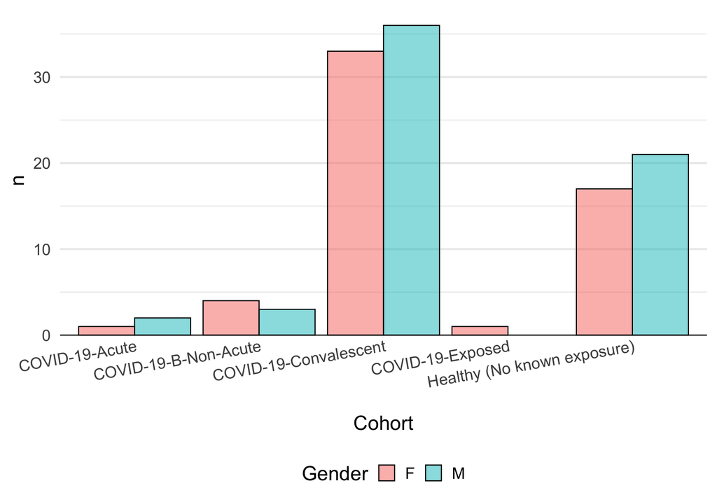

## Lab 5 Exercises

- **T2: Re-create this plot**

```r
pl <- meta_data |>
  mutate(Age_group = cut(
    x = Age,
    breaks = seq(from = 0,
                 to = 100,
                 by = 10))) |>
  drop_na(Gender, Age_group) |>
  count(Gender, Age_group) |>
  ggplot(aes(x = Age_group,
             y = n,
             fill = Gender)) +
  geom_col(position = position_dodge(
    preserve = "single"),
    colour = "black",
    alpha = 0.5) +
  geom_hline(yintercept = 0) +
  theme_minimal(base_size = 20) +
  theme(legend.position = "bottom",
        panel.grid.major.x = element_blank(),
        axis.text.x = element_text(vjust = 5))
```

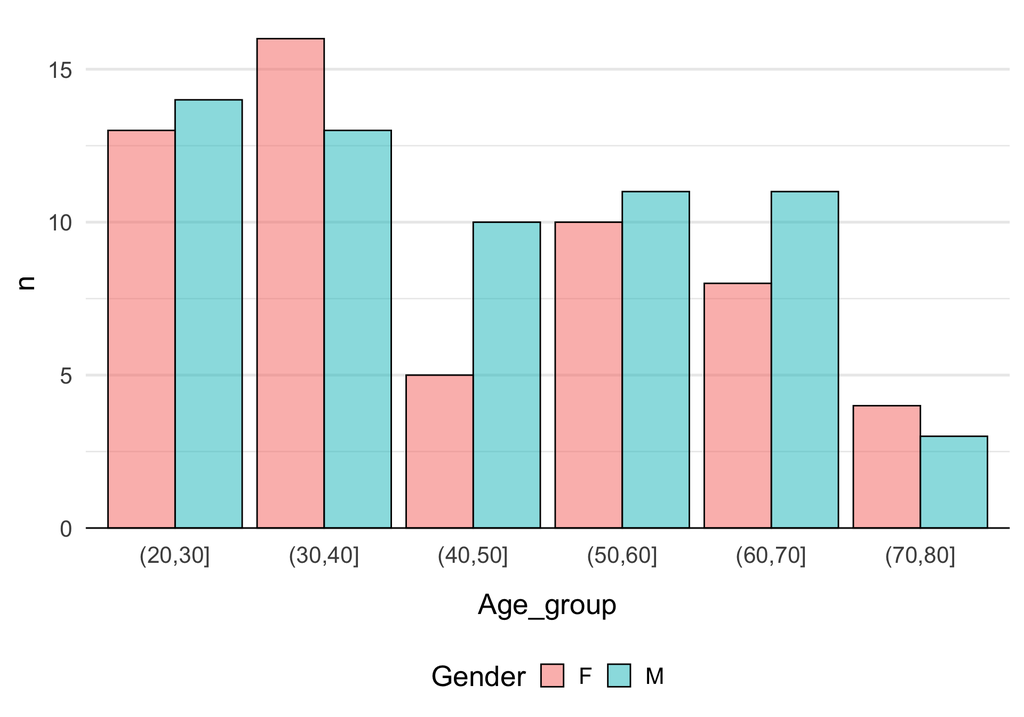

## Lab 5 Exercises

- **T3: Look at the data and create yet another plot as you see fit. Also skip the redundant variables `Subject`, `Cell Type` and `Target Type`**

```r
pl <- meta_data |>
  ggplot(aes(x = Cohort,
             y = Age,
             fill = Gender)) +
  geom_boxplot(position = position_dodge(
    preserve = "single")) +
  theme_minimal(base_size = 20) +
  theme(legend.position = "bottom",
        axis.text.x = element_text(angle = 10,
                                   hjust = 1,
                                   vjust = 1.5))
meta_data <- meta_data |>
  select(-Subject, -`Cell Type`, -`Target Type`)
```

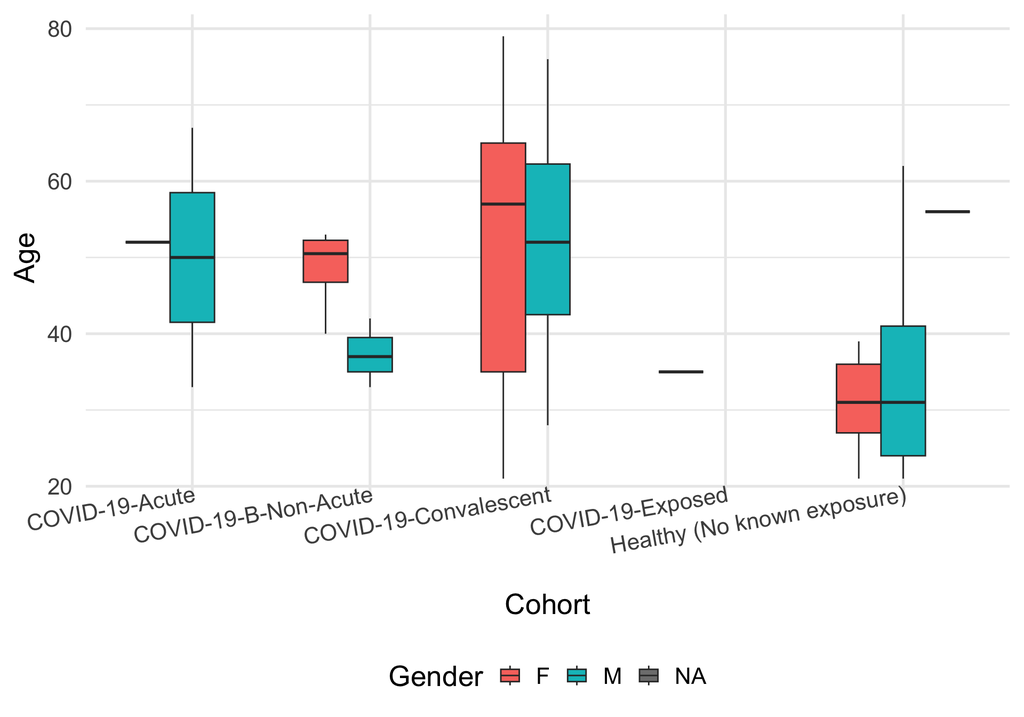

*Note the backticks in selecting variables, which contain spaces!*

## Lab 5 Exercises

```r
library("table1") # <= Yes, this should normally go at the beginning!
meta_data |>
  mutate(Gender = factor(Gender),
         Cohort = factor(Cohort)) |>
  table1(x = formula(~ Gender + Age + Race | Cohort),
         data = _)
```

|  | COVID-19-Acute (N=4) | COVID-19-B-Non-Acute (N=8) | COVID-19-Convalescent (N=90) | COVID-19-Exposed (N=3) | Healthy (No known exposure) (N=39) | Overall (N=144) |
| --- | --- | --- | --- | --- | --- | --- |
| Gender |  |  |  |  |  |  |
| F | 1 (25.0%) | 4 (50.0%) | 33 (36.7%) | 1 (33.3%) | 17 (43.6%) | 56 (38.9%) |
| M | 2 (50.0%) | 3 (37.5%) | 36 (40.0%) | 0 (0%) | 21 (53.8%) | 62 (43.1%) |
| Missing | 1 (25.0%) | 1 (12.5%) | 21 (23.3%) | 2 (66.7%) | 1 (2.6%) | 26 (18.1%) |
| Age |  |  |  |  |  |  |
| Mean (SD) | 50.7 (17.0) | 43.7 (7.74) | 51.5 (15.3) | 35.0 (NA) | 33.3 (9.93) | 44.9 (15.7) |
| Median [Min, Max] | 52.0 [33.0, 67.0] | 42.0 [33.0, 53.0] | 53.0 [21.0, 79.0] | 35.0 [35.0, 35.0] | 31.0 [21.0, 62.0] | 42.0 [21.0, 79.0] |
| Missing | 1 (25.0%) | 1 (12.5%) | 21 (23.3%) | 2 (66.7%) | 0 (0%) | 25 (17.4%) |
| Race |  |  |  |  |  |  |
| African American | 1 (25.0%) | 0 (0%) | 0 (0%) | 0 (0%) | 1 (2.6%) | 2 (1.4%) |
| White | 2 (50.0%) | 7 (87.5%) | 13 (14.4%) | 0 (0%) | 28 (71.8%) | 50 (34.7%) |
| Asian | 0 (0%) | 0 (0%) | 3 (3.3%) | 0 (0%) | 2 (5.1%) | 5 (3.5%) |
| Hispanic or Latino/a | 0 (0%) | 0 (0%) | 1 (1.1%) | 0 (0%) | 0 (0%) | 1 (0.7%) |
| Native Hawaiian or Other Pacific Islander | 0 (0%) | 0 (0%) | 0 (0%) | 1 (33.3%) | 0 (0%) | 1 (0.7%) |
| Black or African American | 0 (0%) | 0 (0%) | 0 (0%) | 0 (0%) | 3 (7.7%) | 3 (2.1%) |
| Mixed Race | 0 (0%) | 0 (0%) | 0 (0%) | 0 (0%) | 1 (2.6%) | 1 (0.7%) |
| Missing | 1 (25.0%) | 1 (12.5%) | 73 (81.1%) | 2 (66.7%) | 4 (10.3%) | 81 (56.3%) |

*Super nice way to quickly get an overview of the data!*

## Lab 5 Exercises

- **T4: Create a new version of the `meta_data`, which with respect to allele-data only contains information on class I and also fix the odd naming, e.g. `HLA-A...9` becomes `A1` oand `HLA-A...10` becomes `A2` and so on for `B1`, `B2`, `C1` and `C2`**

```r
meta_data <- meta_data |>
  select(-matches(match = "D[PQR]")) |> # Regex: D and-then-any-of P or Q or R
  rename("A1" = `HLA-A...9`,
         "A2" = `HLA-A...10`,
         "B1" = `HLA-B...11`,
         "B2" = `HLA-B...12`,
         "C1" = `HLA-C...13`,
         "C2" = `HLA-C...14`)
```

## Lab 5 Exercises

#### The Peptide Details Data

- **Q3: How many observations of how many variables are in the data?**

```r
peptide_data |>
  dim()
```

```
[1] 154320      7
```

## Lab 5 Exercises

- **T5: As before, let’s immediately subset the `peptide_data` to the variables of interest: `TCR BioIdentity`, `Experiment` and `Amino Acids`**

```r
peptide_data <- peptide_data |>
  select(Experiment,
         `TCR BioIdentity`,
         `Amino Acids`)
```

## Lab 5 Exercises

- **Q4: Is this tidy data? Why/why not?**

```r
peptide_data
```

```
# A tibble: 154,320 × 3
   Experiment `TCR BioIdentity`                        `Amino Acids`
   <chr>      <chr>                                    <chr>
 1 eAV93      CASSAQGTGDRGYTF+TCRBV27-01+TCRBJ01-02    ADAGFIKQY,AELEGIQY,LADAG…
 2 eOX56      CASSLVATGNTGELFF+TCRBV07-09+TCRBJ02-02   ADAGFIKQY,AELEGIQY,LADAG…
 3 eAV93      CASSKGTVSGLSG+TCRBV21-01+TCRBJ02-07      ADAGFIKQY,AELEGIQY,LADAG…
 4 eQD124     CALKVGADTQYF+TCRBV30-01+TCRBJ02-03       ADAGFIKQY,AELEGIQY,LADAG…
 5 eAV93      CASSLWASGRGGTGELFF+TCRBV27-01+TCRBJ02-02 ADAGFIKQY,AELEGIQY,LADAG…
 6 eMR16      CASSLLGWEQLDEQFF+TCRBV27-01+TCRBJ02-01   ADAGFIKQY,AELEGIQY,LADAG…
 7 eAV93      CASSSGTGVYGYTF+TCRBV12-X+TCRBJ01-02      ADAGFIKQY,AELEGIQY,LADAG…
 8 eQD123     CASSPLEWEGVTEAFF+TCRBV06-X+TCRBJ01-01    ADAGFIKQY,AELEGIQY,LADAG…
 9 eAV93      CASSFWSSGRGGTDTQYF+TCRBV27-01+TCRBJ02-03 ADAGFIKQY,AELEGIQY,LADAG…
10 eMR15      CASSAGQGASDEQFF+TCRBV07-09+TCRBJ02-01    ADAGFIKQY,AELEGIQY,LADAG…
# ℹ 154,310 more rows
```

## Lab 5 Exercises

- **T6: See if you can find a way to create the below data, from the above**

```r
peptide_data <- peptide_data |>
  separate(col = `TCR BioIdentity`,
           into = c("CDR3b", "V_gene", "J_gene"),
           sep = "\\+") # Note the escape
peptide_data
```

```
# A tibble: 154,320 × 5
   Experiment CDR3b              V_gene     J_gene     `Amino Acids`
   <chr>      <chr>              <chr>      <chr>      <chr>
 1 eAV93      CASSAQGTGDRGYTF    TCRBV27-01 TCRBJ01-02 ADAGFIKQY,AELEGIQY,LADAG…
 2 eOX56      CASSLVATGNTGELFF   TCRBV07-09 TCRBJ02-02 ADAGFIKQY,AELEGIQY,LADAG…
 3 eAV93      CASSKGTVSGLSG      TCRBV21-01 TCRBJ02-07 ADAGFIKQY,AELEGIQY,LADAG…
 4 eQD124     CALKVGADTQYF       TCRBV30-01 TCRBJ02-03 ADAGFIKQY,AELEGIQY,LADAG…
 5 eAV93      CASSLWASGRGGTGELFF TCRBV27-01 TCRBJ02-02 ADAGFIKQY,AELEGIQY,LADAG…
 6 eMR16      CASSLLGWEQLDEQFF   TCRBV27-01 TCRBJ02-01 ADAGFIKQY,AELEGIQY,LADAG…
 7 eAV93      CASSSGTGVYGYTF     TCRBV12-X  TCRBJ01-02 ADAGFIKQY,AELEGIQY,LADAG…
 8 eQD123     CASSPLEWEGVTEAFF   TCRBV06-X  TCRBJ01-01 ADAGFIKQY,AELEGIQY,LADAG…
 9 eAV93      CASSFWSSGRGGTDTQYF TCRBV27-01 TCRBJ02-03 ADAGFIKQY,AELEGIQY,LADAG…
10 eMR15      CASSAGQGASDEQFF    TCRBV07-09 TCRBJ02-01 ADAGFIKQY,AELEGIQY,LADAG…
# ℹ 154,310 more rows
```

## Lab 5 Exercises

- **T7: Add a variable, which counts how many peptides are in each observation of `Amino Acids`**

```r
peptide_data <- peptide_data |>
  mutate(n_peptides = str_count(`Amino Acids`,
                                pattern = ",") + 1)
peptide_data
```

```
# A tibble: 154,320 × 6
   Experiment CDR3b              V_gene     J_gene     `Amino Acids`  n_peptides
   <chr>      <chr>              <chr>      <chr>      <chr>               <dbl>
 1 eAV93      CASSAQGTGDRGYTF    TCRBV27-01 TCRBJ01-02 ADAGFIKQY,AEL…          4
 2 eOX56      CASSLVATGNTGELFF   TCRBV07-09 TCRBJ02-02 ADAGFIKQY,AEL…          4
 3 eAV93      CASSKGTVSGLSG      TCRBV21-01 TCRBJ02-07 ADAGFIKQY,AEL…          4
 4 eQD124     CALKVGADTQYF       TCRBV30-01 TCRBJ02-03 ADAGFIKQY,AEL…          4
 5 eAV93      CASSLWASGRGGTGELFF TCRBV27-01 TCRBJ02-02 ADAGFIKQY,AEL…          4
 6 eMR16      CASSLLGWEQLDEQFF   TCRBV27-01 TCRBJ02-01 ADAGFIKQY,AEL…          4
 7 eAV93      CASSSGTGVYGYTF     TCRBV12-X  TCRBJ01-02 ADAGFIKQY,AEL…          4
 8 eQD123     CASSPLEWEGVTEAFF   TCRBV06-X  TCRBJ01-01 ADAGFIKQY,AEL…          4
 9 eAV93      CASSFWSSGRGGTDTQYF TCRBV27-01 TCRBJ02-03 ADAGFIKQY,AEL…          4
10 eMR15      CASSAGQGASDEQFF    TCRBV07-09 TCRBJ02-01 ADAGFIKQY,AEL…          4
# ℹ 154,310 more rows
```

## Lab 5 Exercises

- **T8: Re-create the following plot**

```r
pl <- peptide_data |>
  ggplot(aes(x = n_peptides)) +
  geom_histogram(binwidth = 1,
                 colour = "black",
                 alpha = 0.5) +
  geom_hline(yintercept = 0) +
  scale_x_continuous(breaks = 1:13) +
  theme_minimal(base_size = 20) +
  theme(panel.grid.minor.x = element_blank(),
        panel.grid.major.x = element_blank(),
        axis.text.x = element_text(vjust = 5)) +
  labs(x = "Number of peptides per observation",
       y = "Counts")
```

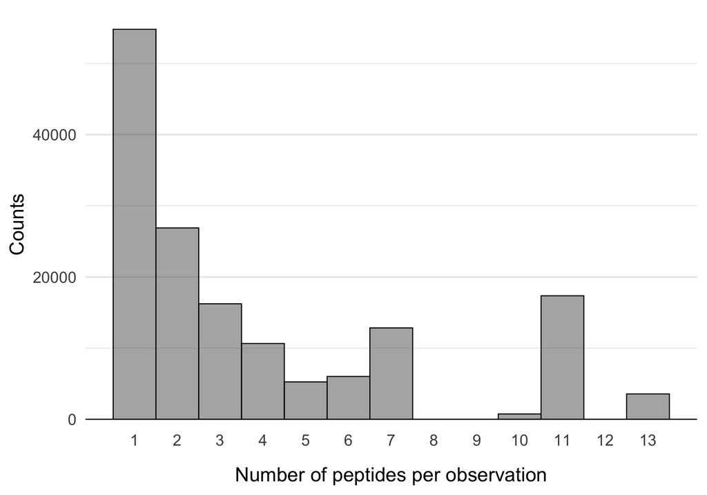

## Lab 5 Exercises

- **Q4: What is the maximum number of peptides assigned to one observation?**

```r
max_n_peptides <- peptide_data |>
  pull(n_peptides) |>
  max()
max_n_peptides
```

```
[1] 13
```

## Lab 5 Exercises

- **T9: Using the `str_c`- and the `seq`-functions, re-create the below**

```r
str_c("peptide_", seq(from = 1, to = 5, by = 1)) # 1:5
```

```
[1] "peptide_1" "peptide_2" "peptide_3" "peptide_4" "peptide_5"
```

## Lab 5 Exercises

- **T10: Use, what you learned about separating in T6 and the vector-of-strings you created in T9 adjusted to the number from Q4 to create the below data**

```r
peptide_data <- peptide_data |>
  separate(col = `Amino Acids`,
           into = str_c("peptide_", 1:max_n_peptides),
           sep = ",")
peptide_data |>
  sample_n(10)
```

```
# A tibble: 10 × 18
   Experiment CDR3b        V_gene J_gene peptide_1 peptide_2 peptide_3 peptide_4
   <chr>      <chr>        <chr>  <chr>  <chr>     <chr>     <chr>     <chr>
 1 eOX52      CASSQAGTGET… TCRBV… TCRBJ… FLNRFTTTL <NA>      <NA>      <NA>
 2 eOX43      CASTDVRPSGR… TCRBV… TCRBJ… TVLSFCAFA VLSFCAFAV <NA>      <NA>
 3 eQD121     CASSPRSGNEK… TCRBV… TCRBJ… HTTDPSFL… <NA>      <NA>      <NA>
 4 eMR13      CASSLAGHTEA… TCRBV… TCRBJ… TFYLTNDV… <NA>      <NA>      <NA>
 5 eOX54      CASSRREGYNE… TCRBV… TCRBJ… ELYSPIFLI LYSPIFLIV QELYSPIFL VQELYSPIF
 6 eQD111     CASSITSAGEQ… TCRBV… TCRBJ… HTTDPSFL… <NA>      <NA>      <NA>
 7 eHO136     CASSLGRGVDT… TCRBV… TCRBJ… AIPTNFTI… AYSNNSIA… IPTNFTISV NSIAIPTNF
 8 eEE226     CASSGQPSRGS… TCRBV… TCRBJ… FPPTSFGPL <NA>      <NA>      <NA>
 9 eOX43      CAISEPRGGYG… TCRBV… TCRBJ… AFPFTIYSL GYINVFAF… INVFAFPF… MGYINVFAF
10 eEE240     CASQTGVGYTF  TCRBV… TCRBJ… AFLLFLVLI FLAFLLFLV FYLCFLAFL FYLCFLAF…
# ℹ 10 more variables: peptide_5 <chr>, peptide_6 <chr>, peptide_7 <chr>,
#   peptide_8 <chr>, peptide_9 <chr>, peptide_10 <chr>, peptide_11 <chr>,
#   peptide_12 <chr>, peptide_13 <chr>, n_peptides <dbl>
```

## Lab 5 Exercises

- **Q5: Now, presumable you got a warning, discuss in your group why that is?**

*Not all have 13, so `R` lets you know this! Thank you `R`* 🙏

## Lab 5 Exercises

- **Q6: With respect to `peptide_n`, discuss in your group, if this is wide- or long-data?**

```r
peptide_data
```

```
# A tibble: 154,320 × 18
   Experiment CDR3b        V_gene J_gene peptide_1 peptide_2 peptide_3 peptide_4
   <chr>      <chr>        <chr>  <chr>  <chr>     <chr>     <chr>     <chr>
 1 eAV93      CASSAQGTGDR… TCRBV… TCRBJ… ADAGFIKQY AELEGIQY  LADAGFIK… TLADAGFIK
 2 eOX56      CASSLVATGNT… TCRBV… TCRBJ… ADAGFIKQY AELEGIQY  LADAGFIK… TLADAGFIK
 3 eAV93      CASSKGTVSGL… TCRBV… TCRBJ… ADAGFIKQY AELEGIQY  LADAGFIK… TLADAGFIK
 4 eQD124     CALKVGADTQYF TCRBV… TCRBJ… ADAGFIKQY AELEGIQY  LADAGFIK… TLADAGFIK
 5 eAV93      CASSLWASGRG… TCRBV… TCRBJ… ADAGFIKQY AELEGIQY  LADAGFIK… TLADAGFIK
 6 eMR16      CASSLLGWEQL… TCRBV… TCRBJ… ADAGFIKQY AELEGIQY  LADAGFIK… TLADAGFIK
 7 eAV93      CASSSGTGVYG… TCRBV… TCRBJ… ADAGFIKQY AELEGIQY  LADAGFIK… TLADAGFIK
 8 eQD123     CASSPLEWEGV… TCRBV… TCRBJ… ADAGFIKQY AELEGIQY  LADAGFIK… TLADAGFIK
 9 eAV93      CASSFWSSGRG… TCRBV… TCRBJ… ADAGFIKQY AELEGIQY  LADAGFIK… TLADAGFIK
10 eMR15      CASSAGQGASD… TCRBV… TCRBJ… ADAGFIKQY AELEGIQY  LADAGFIK… TLADAGFIK
# ℹ 154,310 more rows
# ℹ 10 more variables: peptide_5 <chr>, peptide_6 <chr>, peptide_7 <chr>,
#   peptide_8 <chr>, peptide_9 <chr>, peptide_10 <chr>, peptide_11 <chr>,
#   peptide_12 <chr>, peptide_13 <chr>, n_peptides <dbl>
```

## Lab 5 Exercises

- **T12: From the `peptide_data` data above, with peptide_1, peptide_2, etc. create this data set using one of the data pivoting functions**

```r
peptide_data <- peptide_data |>
  pivot_longer(cols = contains("peptide_"),
               names_to = "peptide_n",
               values_to = "peptide")
peptide_data
```

```
# A tibble: 2,006,160 × 7
   Experiment CDR3b           V_gene     J_gene     n_peptides peptide_n peptide
   <chr>      <chr>           <chr>      <chr>           <dbl> <chr>     <chr>
 1 eAV93      CASSAQGTGDRGYTF TCRBV27-01 TCRBJ01-02          4 peptide_1 ADAGFI…
 2 eAV93      CASSAQGTGDRGYTF TCRBV27-01 TCRBJ01-02          4 peptide_2 AELEGI…
 3 eAV93      CASSAQGTGDRGYTF TCRBV27-01 TCRBJ01-02          4 peptide_3 LADAGF…
 4 eAV93      CASSAQGTGDRGYTF TCRBV27-01 TCRBJ01-02          4 peptide_4 TLADAG…
 5 eAV93      CASSAQGTGDRGYTF TCRBV27-01 TCRBJ01-02          4 peptide_5 <NA>
 6 eAV93      CASSAQGTGDRGYTF TCRBV27-01 TCRBJ01-02          4 peptide_6 <NA>
 7 eAV93      CASSAQGTGDRGYTF TCRBV27-01 TCRBJ01-02          4 peptide_7 <NA>
 8 eAV93      CASSAQGTGDRGYTF TCRBV27-01 TCRBJ01-02          4 peptide_8 <NA>
 9 eAV93      CASSAQGTGDRGYTF TCRBV27-01 TCRBJ01-02          4 peptide_9 <NA>
10 eAV93      CASSAQGTGDRGYTF TCRBV27-01 TCRBJ01-02          4 peptide_… <NA>
# ℹ 2,006,150 more rows
```

## Lab 5 Exercises

- **T13: Now, lose the redundant variables `n_peptides` and `peptide_n`, get rid of the `NA`s in the `peptide` column, and make sure that we only have unique observations (i.e. there are no repeated rows/observations).**

```r
peptide_data <- peptide_data |>
  select(-n_peptides, -peptide_n) |>
  drop_na(peptide) |>
  distinct()
peptide_data
```

```
# A tibble: 583,309 × 5
   Experiment CDR3b            V_gene     J_gene     peptide
   <chr>      <chr>            <chr>      <chr>      <chr>
 1 eAV93      CASSAQGTGDRGYTF  TCRBV27-01 TCRBJ01-02 ADAGFIKQY
 2 eAV93      CASSAQGTGDRGYTF  TCRBV27-01 TCRBJ01-02 AELEGIQY
 3 eAV93      CASSAQGTGDRGYTF  TCRBV27-01 TCRBJ01-02 LADAGFIKQY
 4 eAV93      CASSAQGTGDRGYTF  TCRBV27-01 TCRBJ01-02 TLADAGFIK
 5 eOX56      CASSLVATGNTGELFF TCRBV07-09 TCRBJ02-02 ADAGFIKQY
 6 eOX56      CASSLVATGNTGELFF TCRBV07-09 TCRBJ02-02 AELEGIQY
 7 eOX56      CASSLVATGNTGELFF TCRBV07-09 TCRBJ02-02 LADAGFIKQY
 8 eOX56      CASSLVATGNTGELFF TCRBV07-09 TCRBJ02-02 TLADAGFIK
 9 eAV93      CASSKGTVSGLSG    TCRBV21-01 TCRBJ02-07 ADAGFIKQY
10 eAV93      CASSKGTVSGLSG    TCRBV21-01 TCRBJ02-07 AELEGIQY
# ℹ 583,299 more rows
```

## Lab 5 Exercises

- **Q8: Now how many rows and columns and is this data tidy? Discuss in your group why/why not?**

Super duper tidy!

- Each row is an observation
- Each column is a variable
- Each cell is a value

## Lab 5 Exercises

- **T14: Use the `str_detect()`-function to `filter` the `CDR3b` and `peptide` variables using a `pattern` of `[^ARNDCQEGHILKMFPSTWYV]` and then play with the `negate`-parameter so see what happens**

```r
peptide_data <- peptide_data |>
  filter(str_detect(CDR3b, pattern = "[^ARNDCQEGHILKMFPSTWYV]", negate = TRUE),
         str_detect(peptide, pattern = "[^ARNDCQEGHILKMFPSTWYV]", negate = TRUE))
peptide_data
```

```
# A tibble: 578,357 × 5
   Experiment CDR3b            V_gene     J_gene     peptide
   <chr>      <chr>            <chr>      <chr>      <chr>
 1 eAV93      CASSAQGTGDRGYTF  TCRBV27-01 TCRBJ01-02 ADAGFIKQY
 2 eAV93      CASSAQGTGDRGYTF  TCRBV27-01 TCRBJ01-02 AELEGIQY
 3 eAV93      CASSAQGTGDRGYTF  TCRBV27-01 TCRBJ01-02 LADAGFIKQY
 4 eAV93      CASSAQGTGDRGYTF  TCRBV27-01 TCRBJ01-02 TLADAGFIK
 5 eOX56      CASSLVATGNTGELFF TCRBV07-09 TCRBJ02-02 ADAGFIKQY
 6 eOX56      CASSLVATGNTGELFF TCRBV07-09 TCRBJ02-02 AELEGIQY
 7 eOX56      CASSLVATGNTGELFF TCRBV07-09 TCRBJ02-02 LADAGFIKQY
 8 eOX56      CASSLVATGNTGELFF TCRBV07-09 TCRBJ02-02 TLADAGFIK
 9 eAV93      CASSKGTVSGLSG    TCRBV21-01 TCRBJ02-07 ADAGFIKQY
10 eAV93      CASSKGTVSGLSG    TCRBV21-01 TCRBJ02-07 AELEGIQY
# ℹ 578,347 more rows
```

## Lab 5 Exercises

- **T14: Use the `str_detect()`-function to `filter` the `CDR3b` and `peptide` variables**

```r
clean_amino_acids <- function(x){
  # str_detect(x, pattern = "^[ARNDCQEGHILKMFPSTWYV]+$") will also work
  return( str_detect(x, pattern = "[^ARNDCQEGHILKMFPSTWYV]", negate = TRUE) )
}
peptide_data <- peptide_data |>
  filter(clean_amino_acids(CDR3b),
         clean_amino_acids(peptide))
peptide_data
```

```
# A tibble: 578,357 × 5
   Experiment CDR3b            V_gene     J_gene     peptide
   <chr>      <chr>            <chr>      <chr>      <chr>
 1 eAV93      CASSAQGTGDRGYTF  TCRBV27-01 TCRBJ01-02 ADAGFIKQY
 2 eAV93      CASSAQGTGDRGYTF  TCRBV27-01 TCRBJ01-02 AELEGIQY
 3 eAV93      CASSAQGTGDRGYTF  TCRBV27-01 TCRBJ01-02 LADAGFIKQY
 4 eAV93      CASSAQGTGDRGYTF  TCRBV27-01 TCRBJ01-02 TLADAGFIK
 5 eOX56      CASSLVATGNTGELFF TCRBV07-09 TCRBJ02-02 ADAGFIKQY
 6 eOX56      CASSLVATGNTGELFF TCRBV07-09 TCRBJ02-02 AELEGIQY
 7 eOX56      CASSLVATGNTGELFF TCRBV07-09 TCRBJ02-02 LADAGFIKQY
 8 eOX56      CASSLVATGNTGELFF TCRBV07-09 TCRBJ02-02 TLADAGFIK
 9 eAV93      CASSKGTVSGLSG    TCRBV21-01 TCRBJ02-07 ADAGFIKQY
10 eAV93      CASSKGTVSGLSG    TCRBV21-01 TCRBJ02-07 AELEGIQY
# ℹ 578,347 more rows
```

### DRY

## Lab 5 Exercises

- **T15: Add two new variables to the data, `k_CDR3b` and `k_peptide` each signifying the length of the respective sequences**

```r
peptide_data <- peptide_data |>
  mutate(k_CDR3b = str_length(CDR3b),
         k_peptide = str_length(peptide))
peptide_data
```

```
# A tibble: 578,357 × 7
   Experiment CDR3b            V_gene     J_gene     peptide   k_CDR3b k_peptide
   <chr>      <chr>            <chr>      <chr>      <chr>       <int>     <int>
 1 eAV93      CASSAQGTGDRGYTF  TCRBV27-01 TCRBJ01-02 ADAGFIKQY      15         9
 2 eAV93      CASSAQGTGDRGYTF  TCRBV27-01 TCRBJ01-02 AELEGIQY       15         8
 3 eAV93      CASSAQGTGDRGYTF  TCRBV27-01 TCRBJ01-02 LADAGFIK…      15        10
 4 eAV93      CASSAQGTGDRGYTF  TCRBV27-01 TCRBJ01-02 TLADAGFIK      15         9
 5 eOX56      CASSLVATGNTGELFF TCRBV07-09 TCRBJ02-02 ADAGFIKQY      16         9
 6 eOX56      CASSLVATGNTGELFF TCRBV07-09 TCRBJ02-02 AELEGIQY       16         8
 7 eOX56      CASSLVATGNTGELFF TCRBV07-09 TCRBJ02-02 LADAGFIK…      16        10
 8 eOX56      CASSLVATGNTGELFF TCRBV07-09 TCRBJ02-02 TLADAGFIK      16         9
 9 eAV93      CASSKGTVSGLSG    TCRBV21-01 TCRBJ02-07 ADAGFIKQY      13         9
10 eAV93      CASSKGTVSGLSG    TCRBV21-01 TCRBJ02-07 AELEGIQY       13         8
# ℹ 578,347 more rows
```

## Lab 5 Exercises

- **T16: Re-create this plot**

```r
pl <- peptide_data |>
  ggplot(aes(x = k_CDR3b)) +
  geom_histogram(binwidth = 1,
                 colour = "black",
                 alpha = 0.5) +
  geom_hline(yintercept = 0) +
  theme_minimal(base_size = 20)
```

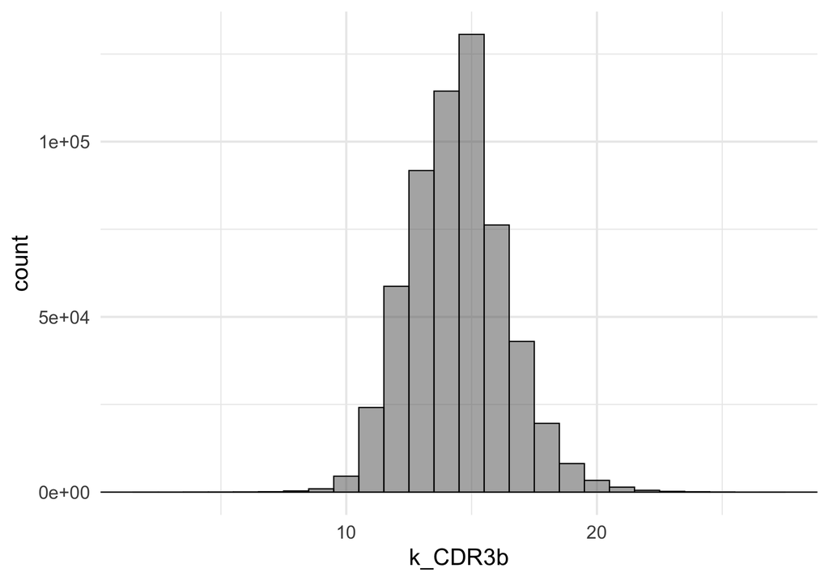

## Lab 5 Exercises

- **T17: Re-create this plot**

```r
pl <- peptide_data |>
  ggplot(aes(x = k_peptide)) +
  geom_histogram(binwidth = 1,
                 colour = "black",
                 alpha = 0.5) +
  geom_hline(yintercept = 0) +
  theme_minimal(base_size = 20)
```

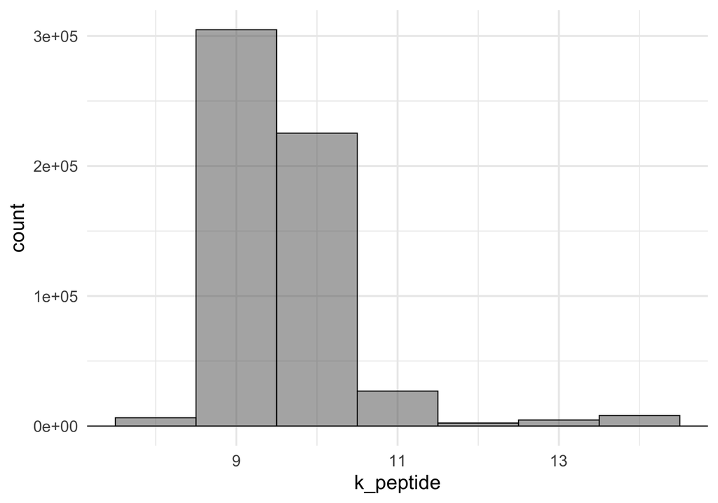

## Lab 5 Exercises

- **Q9: What is the most predominant length of the CDR3b-sequences?**
- **Q10: What is the most predominant length of the peptide-sequences?**
- **Q11: Discuss in your group, if this data set is tidy or not?**

## Lab 5 Exercises

#### Creating one data set from two data sets

Before we move onto using the family of `*_join`-functions you prepared for today, we will just take a quick peek at the meta data again:

```r
meta_data |>
  sample_n(10)
```

```
# A tibble: 10 × 11
   Experiment Cohort        Age Gender Race  A1    A2    B1    B2    C1    C2
   <chr>      <chr>       <dbl> <chr>  <chr> <chr> <chr> <chr> <chr> <chr> <chr>
 1 eDH96      Healthy (N…    53 M      White A*02… A*29… B*15… B*57… C*03… C*07…
 2 ePD86      COVID-19-C…    58 M      White A*02… A*26… B*44… B*51… C*07… C*14…
 3 eHO130     Healthy (N…    28 F      White A*02… A*03… B*07… B*08… C*07… C*07…
 4 eJL161     COVID-19-C…    31 F      White A*01… A*02… B*08… B*13… C*06… C*07…
 5 eQD121     COVID-19-C…    38 M      <NA>  A*01… A*24… B*18… B*57… C*05… C*07…
 6 eQD137     COVID-19-C…    NA <NA>   <NA>  A*01… A*02… B*37… B*44… C*06… C*16…
 7 eMR17      COVID-19-C…    NA <NA>   <NA>  A*01… A*29… B*56… B*57… C*01… C*06…
 8 eMR14      COVID-19-C…    NA <NA>   <NA>  A*03… A*24… B*07… B*57… C*06… C*07…
 9 eHO124     Healthy (N…    62 M      <NA>  A*02… A*03… B*07… B*44… C*07… C*07…
10 eEE226     Healthy (N…    21 F      White A*01… A*02… B*35… B*39… C*04… C*07…
```

- **Q12: Discuss in your group, if this data with respect to the `A1`-, `A2`-, `B1`-, `B2`-, `C1-` and `C2`-variables is a wide- or a long-data format?**

## Lab 5 Exercises

- **T18: use either the `pivot_wider`- or `pivot_longer`-function to create the following data:**

```r
meta_data <- meta_data |>
  pivot_longer(cols = c("A1", "A2", "B1", "B2", "C1", "C2"),
               names_to = "Gene",
               values_to = "Allele")
meta_data
```

```
# A tibble: 864 × 7
   Experiment Cohort                  Age Gender Race  Gene  Allele
   <chr>      <chr>                 <dbl> <chr>  <chr> <chr> <chr>
 1 eAM13      COVID-19-Convalescent    34 F      White A1    A*02:01:01
 2 eAM13      COVID-19-Convalescent    34 F      White A2    A*02:05:01
 3 eAM13      COVID-19-Convalescent    34 F      White B1    B*08:01:01
 4 eAM13      COVID-19-Convalescent    34 F      White B2    B*41:01:01
 5 eAM13      COVID-19-Convalescent    34 F      White C1    C*07:01:01
 6 eAM13      COVID-19-Convalescent    34 F      White C2    C*07:01:01
 7 eAM23      COVID-19-Convalescent    48 M      <NA>  A1    A*11:01:01
 8 eAM23      COVID-19-Convalescent    48 M      <NA>  A2    A*24:02:01
 9 eAM23      COVID-19-Convalescent    48 M      <NA>  B1    B*15:01:01
10 eAM23      COVID-19-Convalescent    48 M      <NA>  B2    B*52:01:01
# ℹ 854 more rows
```

## Lab 5 Exercises

- **Q13: Discuss in your group, which variable(s?) define the same observations between the `peptide_data` and the `meta_data`?**

```
# A tibble: 864 × 7
   Experiment Cohort                  Age Gender Race  Gene  Allele
   <chr>      <chr>                 <dbl> <chr>  <chr> <chr> <chr>
 1 eAM13      COVID-19-Convalescent    34 F      White A1    A*02:01:01
 2 eAM13      COVID-19-Convalescent    34 F      White A2    A*02:05:01
 3 eAM13      COVID-19-Convalescent    34 F      White B1    B*08:01:01
 4 eAM13      COVID-19-Convalescent    34 F      White B2    B*41:01:01
 5 eAM13      COVID-19-Convalescent    34 F      White C1    C*07:01:01
 6 eAM13      COVID-19-Convalescent    34 F      White C2    C*07:01:01
 7 eAM23      COVID-19-Convalescent    48 M      <NA>  A1    A*11:01:01
 8 eAM23      COVID-19-Convalescent    48 M      <NA>  A2    A*24:02:01
 9 eAM23      COVID-19-Convalescent    48 M      <NA>  B1    B*15:01:01
10 eAM23      COVID-19-Convalescent    48 M      <NA>  B2    B*52:01:01
# ℹ 854 more rows
```

```
# A tibble: 578,357 × 7
   Experiment CDR3b            V_gene     J_gene     peptide   k_CDR3b k_peptide
   <chr>      <chr>            <chr>      <chr>      <chr>       <int>     <int>
 1 eAV93      CASSAQGTGDRGYTF  TCRBV27-01 TCRBJ01-02 ADAGFIKQY      15         9
 2 eAV93      CASSAQGTGDRGYTF  TCRBV27-01 TCRBJ01-02 AELEGIQY       15         8
 3 eAV93      CASSAQGTGDRGYTF  TCRBV27-01 TCRBJ01-02 LADAGFIK…      15        10
 4 eAV93      CASSAQGTGDRGYTF  TCRBV27-01 TCRBJ01-02 TLADAGFIK      15         9
 5 eOX56      CASSLVATGNTGELFF TCRBV07-09 TCRBJ02-02 ADAGFIKQY      16         9
 6 eOX56      CASSLVATGNTGELFF TCRBV07-09 TCRBJ02-02 AELEGIQY       16         8
 7 eOX56      CASSLVATGNTGELFF TCRBV07-09 TCRBJ02-02 LADAGFIK…      16        10
 8 eOX56      CASSLVATGNTGELFF TCRBV07-09 TCRBJ02-02 TLADAGFIK      16         9
 9 eAV93      CASSKGTVSGLSG    TCRBV21-01 TCRBJ02-07 ADAGFIKQY      13         9
10 eAV93      CASSKGTVSGLSG    TCRBV21-01 TCRBJ02-07 AELEGIQY       13         8
# ℹ 578,347 more rows
```

```r
intersect(colnames(meta_data), colnames(peptide_data))
```

```
[1] "Experiment"
```

## Lab 5 Exercises

- Once you have agreed upon `Experiment`, then use that knowledge to subset the `meta_data` to the variables-of-interest:

```r
meta_data <- meta_data |>
  select(Experiment, Allele) |>
  distinct()
meta_data
```

```
# A tibble: 761 × 2
   Experiment Allele
   <chr>      <chr>
 1 eAM13      A*02:01:01
 2 eAM13      A*02:05:01
 3 eAM13      B*08:01:01
 4 eAM13      B*41:01:01
 5 eAM13      C*07:01:01
 6 eAM23      A*11:01:01
 7 eAM23      A*24:02:01
 8 eAM23      B*15:01:01
 9 eAM23      B*52:01:01
10 eAM23      C*04:01:01
# ℹ 751 more rows
```

*Here, we are interested in capturing the `Allele`-information*

## Lab 5 Exercises

- Some alleles are e.g. `A*11:01`, whereas others are `B*51:01:02`, let’s snatch the first two fields:
- **T19: Create the following data, according to specifications above:**

```r
meta_data <- meta_data |>
  mutate(Allele_F_1_2 = str_extract(Allele,
                                    # Regex: You're NOT expected to know this!
                                    pattern = "^[ABC]\\*\\d+\\:\\d+")) |>
  filter(Allele_F_1_2 != "") |>
  drop_na()
meta_data
```

```
# A tibble: 748 × 3
   Experiment Allele     Allele_F_1_2
   <chr>      <chr>      <chr>
 1 eAM13      A*02:01:01 A*02:01
 2 eAM13      A*02:05:01 A*02:05
 3 eAM13      B*08:01:01 B*08:01
 4 eAM13      B*41:01:01 B*41:01
 5 eAM13      C*07:01:01 C*07:01
 6 eAM23      A*11:01:01 A*11:01
 7 eAM23      A*24:02:01 A*24:02
 8 eAM23      B*15:01:01 B*15:01
 9 eAM23      B*52:01:01 B*52:01
10 eAM23      C*04:01:01 C*04:01
# ℹ 738 more rows
```

## Lab 5 Exercises

- Some alleles are e.g. `A*11:01`, whereas others are `B*51:01:02`, let’s snatch the first two fields:
- **T19: Create the following data, according to specifications above:**

```r
meta_data <- meta_data |>
  # This will work as well, but think about caveats!
  mutate(Allele_F_1_2 = str_sub(Allele, start = 1, end = 7)) |>
  filter(Allele_F_1_2 != "") |>
  drop_na()
meta_data
```

```
# A tibble: 748 × 3
   Experiment Allele     Allele_F_1_2
   <chr>      <chr>      <chr>
 1 eAM13      A*02:01:01 A*02:01
 2 eAM13      A*02:05:01 A*02:05
 3 eAM13      B*08:01:01 B*08:01
 4 eAM13      B*41:01:01 B*41:01
 5 eAM13      C*07:01:01 C*07:01
 6 eAM23      A*11:01:01 A*11:01
 7 eAM23      A*24:02:01 A*24:02
 8 eAM23      B*15:01:01 B*15:01
 9 eAM23      B*52:01:01 B*52:01
10 eAM23      C*04:01:01 C*04:01
# ℹ 738 more rows
```

## Lab 5 Exercises

The asterisk, i.e. `*` is a rather annoying character because of ambiguity, so:

- **T20: Clean the data a bit more, by removing the asterisk and redundant variables:**

```r
meta_data <- meta_data |>
  mutate(Allele_F_1_2 = str_remove(Allele_F_1_2, "\\*")) |>
  select(-Allele) |>
  rename(Allele = Allele_F_1_2) |>
  distinct()
meta_data
```

```
# A tibble: 748 × 2
   Experiment Allele
   <chr>      <chr>
 1 eAM13      A02:01
 2 eAM13      A02:05
 3 eAM13      B08:01
 4 eAM13      B41:01
 5 eAM13      C07:01
 6 eAM23      A11:01
 7 eAM23      A24:02
 8 eAM23      B15:01
 9 eAM23      B52:01
10 eAM23      C04:01
# ℹ 738 more rows
```

## Lab 5 Exercises

```r
peptide_data
```

```
# A tibble: 578,357 × 7
   Experiment CDR3b            V_gene     J_gene     peptide   k_CDR3b k_peptide
   <chr>      <chr>            <chr>      <chr>      <chr>       <int>     <int>
 1 eAV93      CASSAQGTGDRGYTF  TCRBV27-01 TCRBJ01-02 ADAGFIKQY      15         9
 2 eAV93      CASSAQGTGDRGYTF  TCRBV27-01 TCRBJ01-02 AELEGIQY       15         8
 3 eAV93      CASSAQGTGDRGYTF  TCRBV27-01 TCRBJ01-02 LADAGFIK…      15        10
 4 eAV93      CASSAQGTGDRGYTF  TCRBV27-01 TCRBJ01-02 TLADAGFIK      15         9
 5 eOX56      CASSLVATGNTGELFF TCRBV07-09 TCRBJ02-02 ADAGFIKQY      16         9
 6 eOX56      CASSLVATGNTGELFF TCRBV07-09 TCRBJ02-02 AELEGIQY       16         8
 7 eOX56      CASSLVATGNTGELFF TCRBV07-09 TCRBJ02-02 LADAGFIK…      16        10
 8 eOX56      CASSLVATGNTGELFF TCRBV07-09 TCRBJ02-02 TLADAGFIK      16         9
 9 eAV93      CASSKGTVSGLSG    TCRBV21-01 TCRBJ02-07 ADAGFIKQY      13         9
10 eAV93      CASSKGTVSGLSG    TCRBV21-01 TCRBJ02-07 AELEGIQY       13         8
# ℹ 578,347 more rows
```

```r
meta_data
```

```
# A tibble: 748 × 2
   Experiment Allele
   <chr>      <chr>
 1 eAM13      A02:01
 2 eAM13      A02:05
 3 eAM13      B08:01
 4 eAM13      B41:01
 5 eAM13      C07:01
 6 eAM23      A11:01
 7 eAM23      A24:02
 8 eAM23      B15:01
 9 eAM23      B52:01
10 eAM23      C04:01
# ℹ 738 more rows
```

## Lab 5 Exercises

- **T21: Create a `dplyr`-pipeline, starting with the `peptide_data`, which joins it with the `meta_data` and remember to make sure that you get only unqiue observations of rows. Save this data into a new variable names `peptide_meta_data` (If you get a warning, discuss in your group what it means?)**

```r
peptide_meta_data <- peptide_data |>
  full_join(meta_data,
            by = "Experiment",
            relationship = "many-to-many") |>
  distinct()
peptide_meta_data |>
  sample_n(10)
```

```
# A tibble: 10 × 8
   Experiment CDR3b               V_gene J_gene peptide k_CDR3b k_peptide Allele
   <chr>      <chr>               <chr>  <chr>  <chr>     <int>     <int> <chr>
 1 eXL37      CSASPTGGPNSYTQYF    TCRBV… TCRBJ… QSINFV…      16         9 A03:01
 2 eXL27      CASNGAGGAFF         TCRBV… TCRBJ… VQELYS…      11         9 A02:01
 3 eMR14      CASSSTGEAFF         TCRBV… TCRBJ… VYFLQS…      11         9 A03:01
 4 eOX52      CASSQVEFTDTQYF      TCRBV… TCRBJ… TPSGTW…      14         9 C07:01
 5 eXL27      CASSFWRVWLTVESTGEL… TCRBV… TCRBJ… IELSLI…      20        10 C07:04
 6 eXL30      CASSYGTGSGNTIYF     TCRBV… TCRBJ… FYLCFL…      15         9 B39:01
 7 eXL30      CSVVAPPLQGATGELFF   TCRBV… TCRBJ… LLFVTV…      17        10 C04:01
 8 eXL27      CASSLYRSLSTDTQYF    TCRBV… TCRBJ… FVDGVP…      16         9 B40:01
 9 eXL27      CASSLWLAGDTGELFF    TCRBV… TCRBJ… LEYHDV…      16        10 C07:04
10 eEE226     CASIDGRMNTEAFF      TCRBV… TCRBJ… FLNGSC…      14         9 B35:02
```

## Lab 5 Exercises

### Analysis

Now, that we have the data in a prepared and ready-to-analyse format, let us return to the two burning questions we had:

1. What characterises the peptides binding to the HLAs?
2. What characterises T-cell Receptors binding to the pMHC-complexes?

[figure not shown]

## Lab 5 Exercises

#### Peptides binding to HLA

- **T22: Subset the final `peptide_meta_data`-data to `A02:01` and unique observations of peptides of length 9 and re-create the below sequence logo**

```r
library("ggseqlogo")
pl <- peptide_meta_data |>
  filter(Allele == "A02:01",
         str_length(peptide) == 9) |>
  select(peptide) |>
  distinct() |>
  pull(peptide) |>
  ggseqlogo()
```

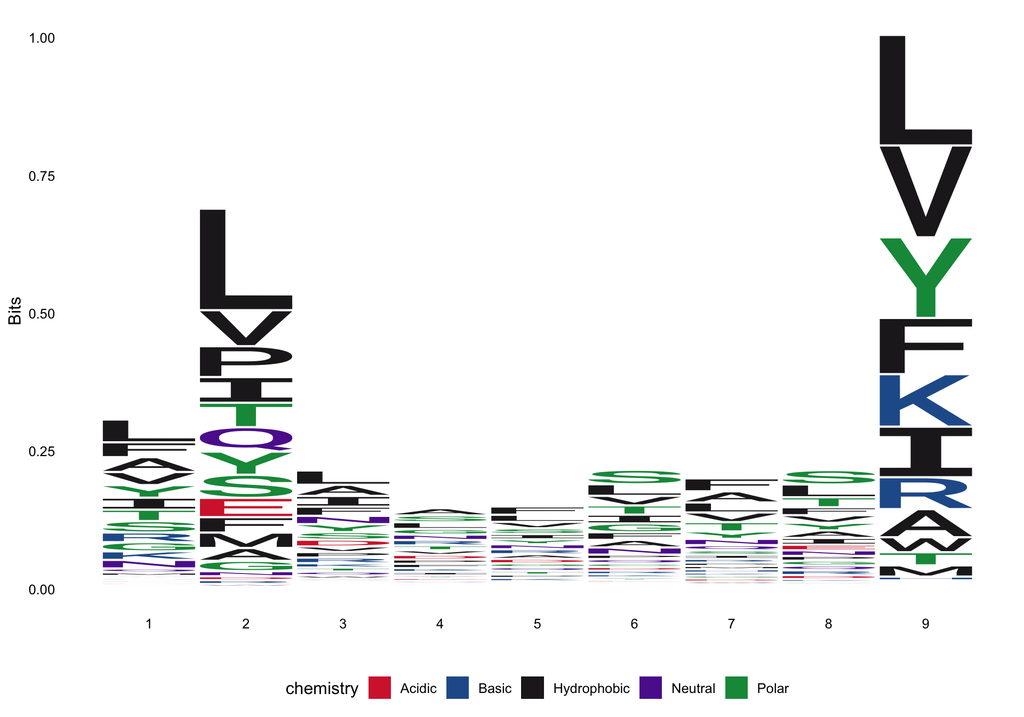

## Lab 5 Exercises

#### Peptides binding to HLA - Rinse-and-Repeat!

- **T23: Repeat for e.g. `B07:02` or another of your favorite alleles**

```r
pl <- peptide_meta_data |>
  filter(Allele == "B07:02",
         str_length(peptide) == 9) |>
  select(peptide) |>
  distinct() |>
  pull(peptide) |>
  ggseqlogo()
```

*The reason, that the logo is actually not correct, is that we’re missing something…*

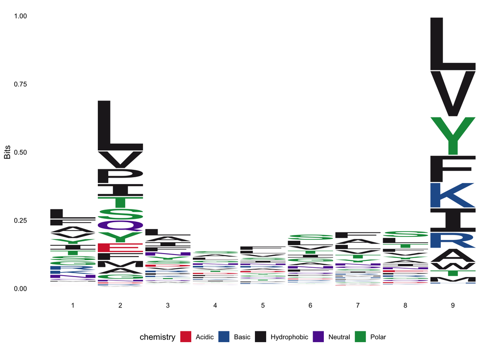

- **Q14: Which positions in the peptide determines binding to HLA?**

## Lab 5 Exercises

#### CDR3b-sequences binding to pMHC

- **T24: Subset the `peptide_meta_data`, such that the length of the CDR3b is 15, the allele is A02:01 and the peptide is LLFLVLIML and re-create the below sequence logo of the CDR3b sequences:**

```r
pl <- peptide_meta_data |>
  filter(k_CDR3b == 15,
         Allele == "A02:01",
         peptide == "LLFLVLIML") |>
  pull(CDR3b) |>
  ggseqlogo()
```

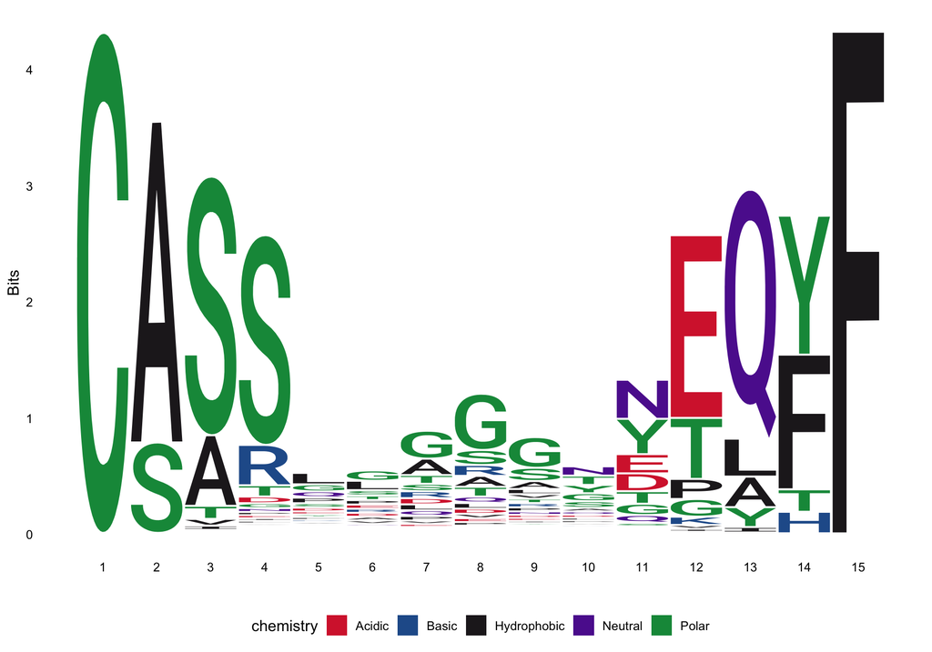

## Epilogue

- I know this overwhelming now, but commit to it and you WILL be plenty rewarded!
- I hope this was at least a glimpse into the flexibility and capabilities of using `tidyverse` for applied Bio Data Science
- …also, noticed something?
- We spend maybe 80% of the time here on dealing with data-wrangling and then once we’re good to go, the analysis wasn’t that time consuming!

*That’s often the way it ends up going, you’ll spend a lot of time on data handling and getting the tidyverse toolbox in your toolbelt, will allow you to be so much more effecient in your data wrangling, so you can get to the fun part as quick as possible!*

## Secret slide: How to succeed in this course!

1. Prepare assigned materials for class
2. Show up for class
3. Pay attention during lectures
4. Do the group exercises
5. Do the assignments
6. Use the assignment feedback
7. …and $\rightarrow$

[figure not shown]